# Análise Ambiental

Diagnóstico de Processos de  
Degradação Ambiental

Luiz Diego Vidal Santos

## Visão Geral da Aula

### Tópicos

- 1 Erosão laminar
- 2 Sulcos
- 3 Ravinas
- 4 Voçorocas
- 5 Compactação
- 6 Perda de cobertura vegetal
- 7 Instabilidade de margens
- 8 Assoreamento
- 9 Degradação de áreas ripárias

**Objetivo da Aula**

Identificar, classificar e diagnosticar feições e processos de degradação ambiental nas vertentes, canais e áreas ripárias.

# 1 - FEIÇÕES EROSIVAS

## Tipologia operacional

### Erosão em lençol e em sulcos

| Forma | Mecanismo | Profundidade |
| --- | --- | --- |
| Splash | Impacto da gota → desagregação e selamento | mm |
| Laminar | Escoamento difuso remove camada superficial | mm-cm |
| Sulcos | Concentração do escoamento em fluxo linear | cm |

Até a fase de sulcos, a erosão ainda é **reversível com manejo agronômico** (cobertura, terraços, plantio em nível).

### Ravinas

- Incisões lineares de 0,1 a 1 m de profundidade.
- Concentram fluxo e evoluem regressivamente.
- Necessitam **intervenção estrutural-vegetativa**.

**Voçorocas**

- Feições > 1 m de profundidade que **atingem o lençol freático**.
- Combinam erosão superficial + subterrânea (piping).
- Evolução regressiva por **avanço de cabeceira**.
- Tipologia:

| Tipo | Característica |
| --- | --- |
| Conectada à drenagem | Ligação direta com curso d’água |
| Desconectada | Sem conexão com canal natural |
| Em arena | Forma de anfiteatro, paredes íngremes |
| Linear | Predomina largura > profundidade |

> Controle por **paliçadas permeáveis**, **drenos verdes** e **estabilização de cabeceiras**.

[figure not shown]

## Compactação e perda de cobertura

### Compactação

- Causada por **pisoteio**, **tráfego de máquinas** e **manejo inadequado da umidade**.
- Sintomas: redução de macroporos, aumento da Ds, restrição radicular.
- Diagnóstico: penetrômetro, anéis de Kopecky, infiltração.
- Correção: escarificação controlada, planta de cobertura com sistema radicular profundo (*Brachiaria*, nabo forrageiro).

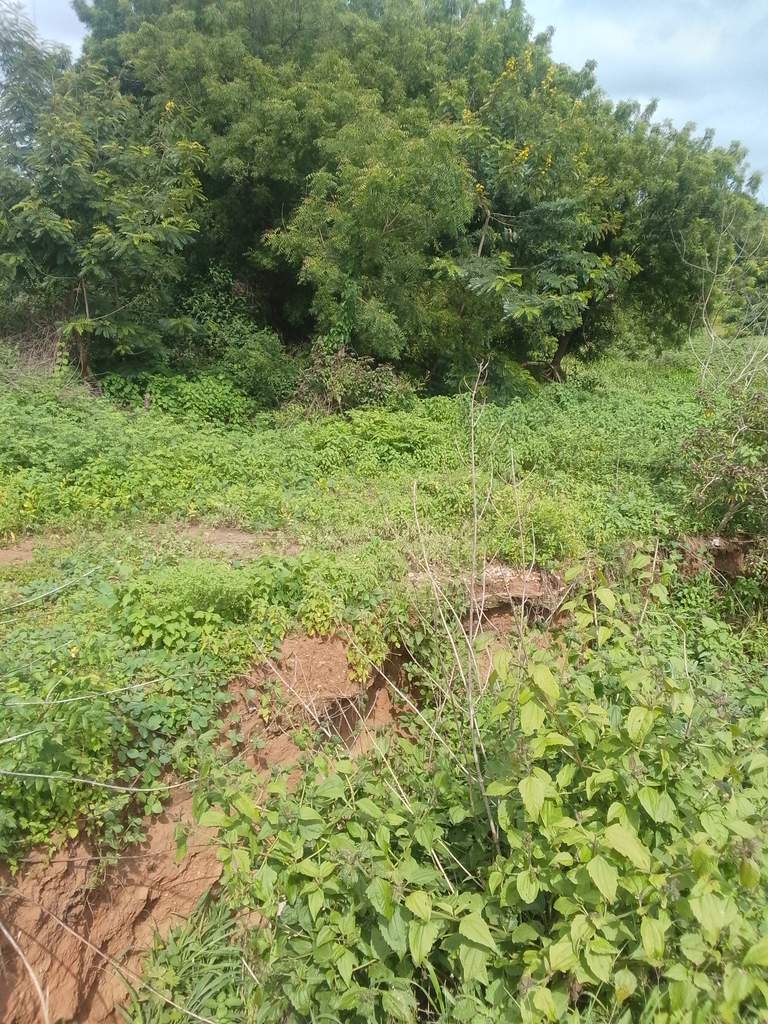

### Perda de cobertura vegetal

- < 30% de cobertura ativa → aceleração do splash.
- Diagnóstico em SR: NDVI, NDII, MapBiomas.
- Plantio direto e cobertura morta são estratégias chave de proteção.

**Mapeamento de feições**

Protocolo recomendado:

1. Imagem de alta resolução (drone, *Maxar*, *Planet*).
2. Vetorização das feições (polígonos para voçorocas, linhas para ravinas).
3. Atributos: comprimento, largura média, profundidade máxima, atividade (ativa / estabilizada).
4. Cálculo de **densidade de feições** por sub-bacia.
5. Hierarquização por **urgência de intervenção**.

# 2 - DEGRADAÇÃO HIDROSSEDIMENTOLÓGICA

## Margens, assoreamento e áreas ripárias

### Instabilidade de margens

| Mecanismo | Indicador |
| --- | --- |
| Solapamento basal | Concavidade na base, exposição radicular |
| Cisalhamento | Trincas paralelas à margem |
| Toppling | Inclinação de árvores em direção à água |
| Liquefação | Material satur. desagregado |
| Piping | Furos e túnel subterrâneo |

### Assoreamento

- Deposição de sedimentos em **canais**, **reservatórios** e **planícies**.
- Reduz seção hidráulica e capacidade de armazenamento.
- Indicadores de campo: barras arenosas, soterramento de macrófitas, alargamento do canal.

**Degradação de áreas ripárias**

- Supressão de mata ciliária + pisoteio bovino + cana/soja até a margem = círculo vicioso.
- Consequências:
  - Aumento da temperatura da água
  - Redução do OD
  - Perda de filtragem (nutrientes, sedimentos, agrotóxicos)
  - Desconexão ecológica
- Marco legal: APP do Código Florestal.
- Recuperação: **plantio adensado de nativas** + **bioengenharia de margens**.

## Síntese: mapa de degradação

### Procedimento integrador

1. **Indicadores físicos** → fragilidade potencial.
2. **Indicadores de uso** → cobertura, manejo, conflitos APP.
3. **Inventario de feições** → vetores e atributos.
4. **Overlay em SIG** → mapa de **grau de degradação**.
5. Critérios para classificação:
   - Sem degradação detectável
   - Degradação incipiente (sulcos, perda de cobertura)
   - Degradação moderada (ravinas isoladas, cobertura < 50%)
   - Degradação severa (voçorocas ativas, solo exposto, perda de horizontes)

**Entrada para o PRAD**

O diagnóstico desta aula alimenta diretamente o **Plano de Recuperação de Áreas Degradadas** ao identificar:

- Tipo de degradação predominante.
- Causas associadas (uso, manejo, condições do meio físico).
- Hierarquização de áreas prioritárias.
- Seleção de técnicas.

# Referências

## Bibliografia da aula

- GUERRA, A. J. T.; SILVA, A. S.; BOTELHO, R. G. M. (org.). **Erosão e conservação dos solos**: conceitos, temas e aplicações. Rio de Janeiro: Bertrand Brasil, 1999.
- BERTONI, J.; LOMBARDI NETO, F. **Conservação do solo**. São Paulo: Ícone, 2012.
- GUERRA, A. J. T.; CUNHA, S. B. (org.). **Geomorfologia e meio ambiente**. Rio de Janeiro: Bertrand Brasil, 1996.
- ROSS, J. L. S. Análise empírica da fragilidade dos ambientes naturais e antropizados. **Revista do Departamento de Geografia**, v. 8, 1994. DOI: 10.7154/RDG.1994.0008.0006.
- CAVALCANTI, A. P. B. **Métodos e técnicas da análise ambiental**. Teresina: EDUFPI, 2006.